# Assignment5

Rabin Paudel

11/1/2021

## Problem 1 (20pts)

#### A snippet of the data is given below

```r
## install.packages("alr4")
library(ggplot2)
library(dplyr)
library(alr4)
data(MWwords)
```

```r
newData <- select(MWwords, Hamilton, HamiltonRank) %>% head(50)
```

### 1.(a) sing only the 50 most frequent words in Hamilton’s work, fit a simple

### linear regression model with log(Hamilton) as the response variable.

#### We fit the simple linear regression model with log(Hamilton) as the

#### response variable.

```r
model <- lm(log(newData$Hamilton) ~ newData$HamiltonRank, data = MWwords)
summary(model)
```

```
##
## Call:
## lm(formula = log(newData$Hamilton) ~ newData$HamiltonRank, data = MWwords)
##
## Residuals:
##      Min       1Q   Median       3Q      Max
## -0.39124 -0.23684 -0.07905  0.18997  1.34197
##
## Coefficients:
##                       Estimate Std. Error t value Pr(>|t|)
## (Intercept)           3.228707   0.101418   31.84   <2e-16 ***
## newData$HamiltonRank -0.056852   0.003461  -16.42   <2e-16 ***
## ---
## Signif. codes:  0 '***' 0.001 '**' 0.01 '*' 0.05 '.' 0.1 ' ' 1
##
## Residual standard error: 0.3532 on 48 degrees of freedom
## Multiple R-squared:  0.8489, Adjusted R-squared:  0.8458
## F-statistic: 269.8 on 1 and 48 DF,  p-value: < 2.2e-16
```

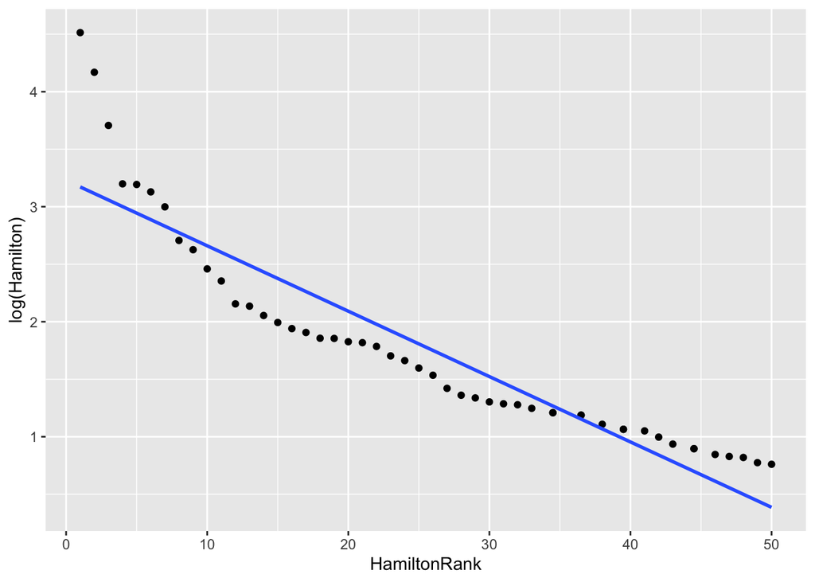

```r
fg <- ggplot(newData, aes(HamiltonRank, log(Hamilton)))
fg + geom_point() + geom_smooth(method = "lm", se = FALSE)
```

### 1.(b) is the empirical law γ ≈1 likely to be “correct’ ’ ? Justify

#### Both log of the rank and log of frequency both closer to the intercept

#### so that the the empirical law γ ≈1 likely to be “correct”.

```r
modele <- lm(log(newData$Hamilton) ~ log(newData$HamiltonRank), data = MWwords)
modele
```

```
##
## Call:
## lm(formula = log(newData$Hamilton) ~ log(newData$HamiltonRank),
##     data = MWwords)
##
## Coefficients:
##               (Intercept)  log(newData$HamiltonRank)
##                     4.771                     -1.008
```

```r
summary(modele)
```

```
##
## Call:
## lm(formula = log(newData$Hamilton) ~ log(newData$HamiltonRank),
##     data = MWwords)
##
## Residuals:
##       Min        1Q    Median        3Q       Max
## -0.257413 -0.050288 -0.001563  0.043448  0.188268
##
## Coefficients:
##                           Estimate Std. Error t value Pr(>|t|)
## (Intercept)                4.77124    0.03948  120.84   <2e-16 ***
## log(newData$HamiltonRank) -1.00764    0.01275  -79.04   <2e-16 ***
## ---
## Signif. codes:  0 '***' 0.001 '**' 0.01 '*' 0.05 '.' 0.1 ' ' 1
##
## Residual standard error: 0.07934 on 48 degrees of freedom
## Multiple R-squared:  0.9924, Adjusted R-squared:  0.9922
## F-statistic:  6248 on 1 and 48 DF,  p-value: < 2.2e-16
```

### 1.(c) Repeat part (a) and (b), first for the 75 most frequent words in

### Hamilton’s work and then for the 100 most frequent words in Hamilton work’s.

### Is the relationship posited by Zipf still reasonable in these cases ?

```r
new1Data <- select(MWwords, Hamilton, HamiltonRank) %>% head(75)
model1 <- lm(log(new1Data$Hamilton) ~ new1Data$HamiltonRank, data = MWwords)
summary(model1)
```

```
##
## Call:
## lm(formula = log(new1Data$Hamilton) ~ new1Data$HamiltonRank,
##     data = MWwords)
##
## Residuals:
##      Min       1Q   Median       3Q      Max
## -0.36312 -0.24476 -0.05567  0.15039  1.57086
##
## Coefficients:
##                        Estimate Std. Error t value Pr(>|t|)
## (Intercept)            2.988102   0.077871   38.37   <2e-16 ***
## new1Data$HamiltonRank -0.045143   0.001781  -25.35   <2e-16 ***
## ---
## Signif. codes:  0 '***' 0.001 '**' 0.01 '*' 0.05 '.' 0.1 ' ' 1
##
## Residual standard error: 0.3338 on 73 degrees of freedom
## Multiple R-squared:  0.898,  Adjusted R-squared:  0.8966
## F-statistic: 642.8 on 1 and 73 DF,  p-value: < 2.2e-16
```

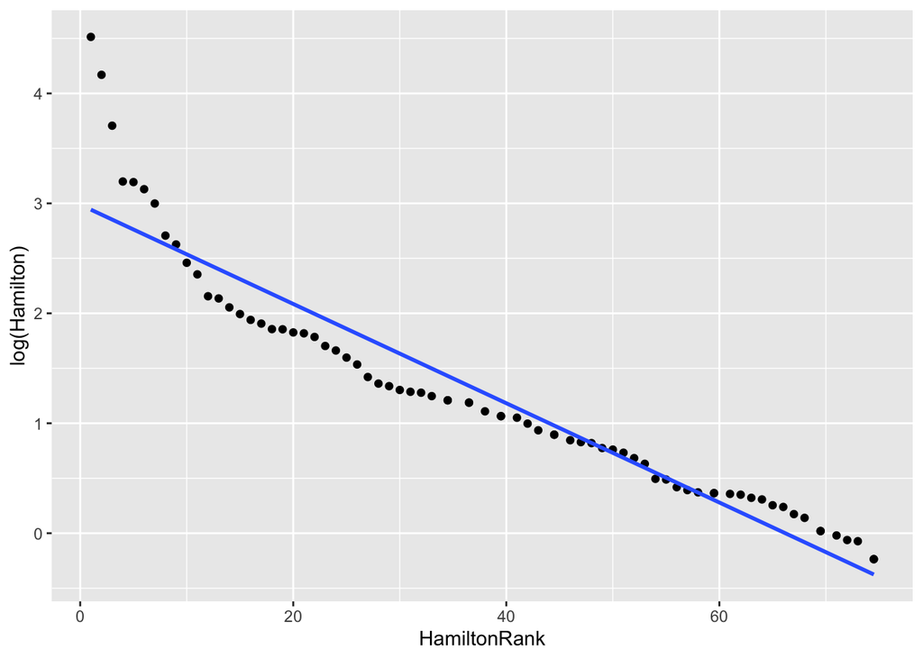

```r
fg1 <- ggplot(new1Data, aes(HamiltonRank, log(Hamilton)))
fg1 + geom_point() + geom_smooth(method = "lm", se = FALSE)
```

```r
new2Data <- select(MWwords, Hamilton, HamiltonRank) %>% head(100)
model2 <- lm(log(new2Data$Hamilton) ~ new2Data$HamiltonRank, data = MWwords)
summary(model1)
```

[output not shown]

[output not shown]

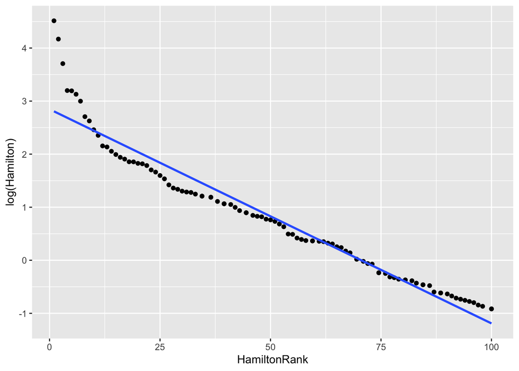

```r
fg1 <- ggplot(new2Data, aes(HamiltonRank, log(Hamilton)))
fg1 + geom_point() + geom_smooth(method = "lm", se = FALSE)
```

#### Yes, the relationship posited by Zipf still responable in these case

#### Residual standard error small, adj R sqare also big, median value is small,

#### bothcase, p-value is small that way highly significant.

### 1.(d) Now investigate Zipf law for the Simpson Frequency Dictionary dataset.

### You will need to do some preprocessing and possibly cleaning of the raw data

### (in particular the numbers in the Frequency column 1 of this dataset;

### your stringr skills might come in handy here

```r
library(stringr)
library(dplyr)
library(tidyr)
READ <- read.csv("https://pastebin.com/raw/anKcMdvk", header = FALSE,
                skip = 5, stringsAsFactors = TRUE)
READ %>% head(30)
```

```
##                                                V1
## 1  1      the                            (107946)
## 2   2      you                            (98068)
## 3   3      i                              (91502)
## 4   4      a                              (79241)
## 5   5      to                             (70362)
## 6   6      and                            (47916)
## 7   7      of                             (42175)
## 8   8      it                             (36497)
## 9   9      in                             (32503)
## 10  10     my                             (32254)
## 11  11     that                           (32083)
## 12  12     is                             (31533)
## 13  13     this                           (29902)
## 14  14     me                             (28208)
```

[output cut: 16 more lines]

#### We need to clean the data set, so I am going to clean the data Trying to

#### first 500 values.

```r
Rank <- as.numeric(str_sub(READ$V1, 1, 7), replace = TRUE)
data.frame(Rank) %>% head(10)
```

```
##    Rank
## 1     1
## 2     2
## 3     3
## 4     4
## 5     5
## 6     6
## 7     7
## 8     8
## 9     9
## 10   10
```

```r
val <- data.frame(Rank)

Word <- str_sub(READ$V1, 8, 25)
Word %>% head(10)
```

```
##  [1] "the               " "you               " "i                 "
##  [4] "a                 " "to                " "and               "
##  [7] "of                " "it                " "in                "
## [10] "my                "
```

```r
val1 <- data.frame(Word)

Frequency <- as.numeric(str_sub(READ$V1, 40, -2), replace = TRUE)
Frequency %>% head(10)
```

```
##  [1] 107946  98068  91502  79241  70362  47916  42175  36497  32503  32254
```

```r
val2 <- data.frame(Frequency)

ADDDATA <- data.frame(c(val, val1, val2))
ADDDATA %>% head(10)
```

```
##    Rank               Word Frequency
## 1     1 the                   107946
## 2     2 you                    98068
## 3     3 i                      91502
## 4     4 a                      79241
## 5     5 to                     70362
## 6     6 and                    47916
## 7     7 of                     42175
## 8     8 it                     36497
## 9     9 in                     32503
## 10   10 my                     32254
```

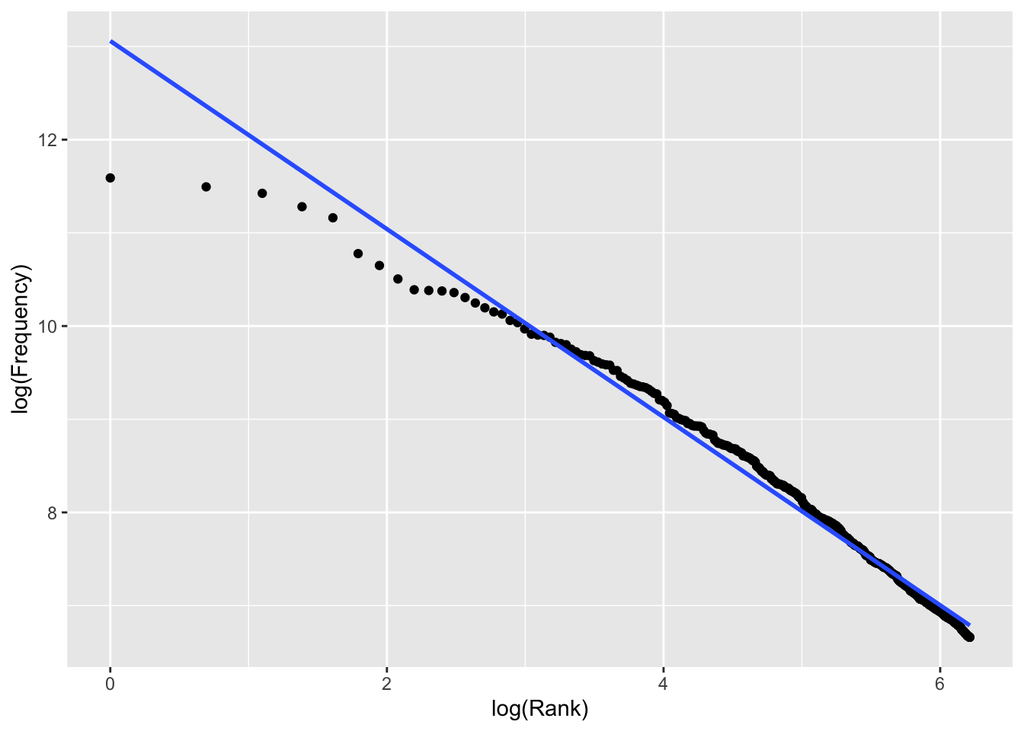

```r
jk <- ADDDATA %>% head(500)

fg3 <- ggplot(jk, aes(log(Rank), log(Frequency)))

fg3 + geom_point() + geom_smooth(method = "lm", se = FALSE)
```

```r
modele1 <- lm(log(Frequency) ~ Rank, data = jk)
summary(modele1)
```

```
##
## Call:
## lm(formula = log(Frequency) ~ Rank, data = jk)
##
## Residuals:
##     Min      1Q  Median      3Q     Max
## -0.3667 -0.2755 -0.1187  0.2059  2.2144
##
## Coefficients:
##               Estimate Std. Error t value Pr(>|t|)
## (Intercept)  9.3813891  0.0339461  276.36   <2e-16 ***
## Rank        -0.0063599  0.0001174  -54.16   <2e-16 ***
## ---
## Signif. codes:  0 '***' 0.001 '**' 0.01 '*' 0.05 '.' 0.1 ' ' 1
##
## Residual standard error: 0.379 on 498 degrees of freedom
## Multiple R-squared:  0.8549, Adjusted R-squared:  0.8546
## F-statistic:  2934 on 1 and 498 DF,  p-value: < 2.2e-16
```

#### Adj R square is good enough, p- value small enough data is significant, Me-

#### dian value close to jeso, residual standard error = 0.379 (small) so that

#### the data look like normal. So, the data follows Zipf law.

## Problem 2 (20 pts)

### This problem uses the following Kelley Blue Book dataset on the selling

### price of used GM cars. The data is available online here. You can read in

### the data using the following code chunk.

```r
kbb <- read.csv("https://bit.ly/3GknAkw", header = T, sep = ",")
kbb %>% head(10)
```

```
##       Price Mileage  Make   Model     Trim  Type Cylinder Liter Doors Cruise
## 1  17314.10    8221 Buick Century Sedan 4D Sedan        6   3.1     4    yes
## 2  17542.04    9135 Buick Century Sedan 4D Sedan        6   3.1     4    yes
## 3  16218.85   13196 Buick Century Sedan 4D Sedan        6   3.1     4    yes
## 4  16336.91   16342 Buick Century Sedan 4D Sedan        6   3.1     4    yes
## 5  16339.17   19832 Buick Century Sedan 4D Sedan        6   3.1     4    yes
## 6  15709.05   22236 Buick Century Sedan 4D Sedan        6   3.1     4    yes
## 7  15230.00   22576 Buick Century Sedan 4D Sedan        6   3.1     4    yes
## 8  15048.04   22964 Buick Century Sedan 4D Sedan        6   3.1     4    yes
## 9  14862.09   24021 Buick Century Sedan 4D Sedan        6   3.1     4    yes
## 10 15295.02   27325 Buick Century Sedan 4D Sedan        6   3.1     4    yes
##    Sound Leather
## 1    yes     yes
## 2    yes      no
## 3    yes      no
## 4     no      no
## 5     no     yes
## 6    yes      no
## 7    yes      no
## 8    yes      no
## 9     no     yes
## 10   yes     yes
```

### Using this data, what is the “best” (linear) model you can find for

### predicting the sell price ? Note that this is an open-ended problem.

#### We now simple model predicting sell price to get moodle only with Mileage

```r
mod0 <- lm(Price~ Mileage, data = kbb)
summary(mod0)
```

```
##
## Call:
## lm(formula = Price ~ Mileage, data = kbb)
##
## Residuals:
##    Min     1Q Median     3Q    Max
## -13905  -7254  -3520   5188  46091
##
## Coefficients:
##               Estimate Std. Error t value Pr(>|t|)
## (Intercept)  2.476e+04  9.044e+02  27.383  < 2e-16 ***
## Mileage     -1.725e-01  4.215e-02  -4.093 4.68e-05 ***
## ---
## Signif. codes:  0 '***' 0.001 '**' 0.01 '*' 0.05 '.' 0.1 ' ' 1
##
## Residual standard error: 9789 on 802 degrees of freedom
## Multiple R-squared:  0.02046,    Adjusted R-squared:  0.01924
## F-statistic: 16.75 on 1 and 802 DF,  p-value: 4.685e-05
```

#### To find mean absolute error of mod0

```r
mae_mod0 <- mean(abs(kbb$Price - mod0$fitted.values))
mae_mod0
```

```
## [1] 7596.28
```

#### This value small Adj R^2 not good enough.

#### Residual Standard error = 9789 (Big)

#### P-value small highly significant

#### Higher median value (not good enough)

#### F and t statistic good enough

#### Negative correlation Price and Milege (sloop of milage is negative)

#### ## Mean Absolute Error = 7596.28 (high)

#### Next model mod1 add variable Cylinder + Liter + Doors + some dummy Variable.

```r
mod1 <- update(mod0, .~. + Cylinder + Liter + Doors + Cruise + Sound + Leather)
summary(mod1)
```

```
##
## Call:
## lm(formula = Price ~ Mileage + Cylinder + Liter + Doors + Cruise +
##     Sound + Leather, data = kbb)
##
## Residuals:
##    Min     1Q Median     3Q    Max
## -13278  -5615  -1556   3996  32819
##
## Coefficients:
##               Estimate Std. Error t value Pr(>|t|)
## (Intercept)  6.759e+03  1.877e+03   3.601 0.000337 ***
## Mileage     -1.698e-01  3.187e-02  -5.326 1.31e-07 ***
## Cylinder     3.792e+03  6.832e+02   5.551 3.87e-08 ***
## Liter       -7.872e+02  8.671e+02  -0.908 0.364196
## Doors       -1.543e+03  3.205e+02  -4.814 1.77e-06 ***
## Cruiseyes    6.289e+03  6.580e+02   9.558  < 2e-16 ***
## Soundyes    -1.994e+03  5.718e+02  -3.487 0.000515 ***
## Leatheryes   3.349e+03  5.977e+02   5.604 2.89e-08 ***
## ---
## Signif. codes:  0 '***' 0.001 '**' 0.01 '*' 0.05 '.' 0.1 ' ' 1
##
## Residual standard error: 7388 on 796 degrees of freedom
## Multiple R-squared:  0.4463, Adjusted R-squared:  0.4414
## F-statistic: 91.64 on 7 and 796 DF,  p-value: < 2.2e-16
```

```r
mae_mod1 <- mean(abs(kbb$Price - mod1$fitted.values))
mae_mod1
```

```
## [1] 5799.617
```

#### The variable Liter is not significant higher p-value so i am going to

#### Remove the variable.

```r
mod1 <- update(mod0, .~. + Cylinder + Doors + Cruise + Sound + Leather)
summary(mod1)
```

```
##
## Call:
## lm(formula = Price ~ Mileage + Cylinder + Doors + Cruise + Sound +
##     Leather, data = kbb)
##
## Residuals:
##    Min     1Q Median     3Q    Max
## -13104  -5566  -1544   3877  33349
##
## Coefficients:
##               Estimate Std. Error t value Pr(>|t|)
## (Intercept)  7.323e+03  1.771e+03   4.135 3.92e-05 ***
## Mileage     -1.705e-01  3.186e-02  -5.352 1.14e-07 ***
## Cylinder     3.200e+03  2.030e+02  15.765  < 2e-16 ***
## Doors       -1.463e+03  3.083e+02  -4.747 2.45e-06 ***
## Cruiseyes    6.206e+03  6.515e+02   9.525  < 2e-16 ***
## Soundyes    -2.024e+03  5.707e+02  -3.547 0.000412 ***
## Leatheryes   3.327e+03  5.971e+02   5.572 3.45e-08 ***
## ---
## Signif. codes:  0 '***' 0.001 '**' 0.01 '*' 0.05 '.' 0.1 ' ' 1
##
## Residual standard error: 7387 on 797 degrees of freedom
## Multiple R-squared:  0.4457, Adjusted R-squared:  0.4415
## F-statistic: 106.8 on 6 and 797 DF,  p-value: < 2.2e-16
```

#### We don’t see any big change after removing the variable Liter.

#### To create another model

```r
mod2 <- update(mod1, .~. + Make + Model + Trim + Type + Cruise + Sound + Leather)
summary(mod2)
```

```
##
## Call:
## lm(formula = Price ~ Mileage + Cylinder + Doors + Cruise + Sound +
##     Leather + Make + Model + Trim + Type, data = kbb)
##
## Residuals:
##     Min      1Q  Median      3Q     Max
## -6523.2  -471.4    18.1   468.9  4425.1
##
## Coefficients: (19 not defined because of singularities)
##                           Estimate Std. Error t value Pr(>|t|)
## (Intercept)              3.019e+04  1.616e+03  18.682  < 2e-16 ***
## Mileage                 -1.854e-01  4.051e-03 -45.754  < 2e-16 ***
## Cylinder                 1.173e+03  2.028e+02   5.786 1.07e-08 ***
## Doors                   -2.706e+03  2.985e+02  -9.066  < 2e-16 ***
## Cruiseyes                6.940e+01  1.015e+02   0.684 0.494443
## Soundyes                 2.113e+02  7.976e+01   2.649 0.008257 **
## Leatheryes               2.954e+02  9.287e+01   3.180 0.001533 **
## MakeCadillac             3.169e+04  7.497e+02  42.277  < 2e-16 ***
## MakeChevrolet           -6.518e+03  4.841e+02 -13.464  < 2e-16 ***
## MakePontiac             -5.606e+03  7.026e+02  -7.979 5.71e-15 ***
## MakeSAAB                 5.189e+03  6.980e+02   7.434 2.96e-13 ***
## MakeSaturn              -7.037e+03  5.689e+02 -12.371  < 2e-16 ***
## Model9_3 HO              8.070e+02  7.206e+02   1.120 0.263139
## Model9_5                 2.245e+03  8.292e+02   2.707 0.006950 **
## Model9_5 HO              2.799e+03  8.252e+02   3.392 0.000731 ***
## Model9-2X AWD           -3.002e+03  9.849e+02  -3.048 0.002388 **
## ModelAVEO               -4.073e+03  5.968e+02  -6.825 1.85e-11 ***
## ModelBonneville          3.059e+03  7.036e+02   4.348 1.57e-05 ***
## ModelCavalier           -2.074e+03  5.559e+02  -3.731 0.000205 ***
## ModelCentury            -7.216e+03  4.041e+02 -17.859  < 2e-16 ***
## ModelClassic            -5.456e+02  6.399e+02  -0.853 0.394138
## ModelCobalt             -1.120e+03  5.562e+02  -2.014 0.044362 *
## ModelCorvette            1.730e+04  6.416e+02  26.958  < 2e-16 ***
## ModelCST-V              -1.222e+04  6.303e+02 -19.388  < 2e-16 ***
## ModelCTS                -2.503e+04  7.507e+02 -33.343  < 2e-16 ***
## ModelDeville            -2.423e+04  6.300e+02 -38.460  < 2e-16 ***
## ModelG6                  1.916e+03  6.890e+02   2.780 0.005568 **
## ModelGrand Am           -4.957e+02  5.767e+02  -0.860 0.390249
## ModelGrand Prix         -6.114e+02  6.913e+02  -0.884 0.376721
```

[output cut: 55 more lines]

```
## TrimSportwagon 4D               NA         NA      NA       NA
## TrimSS Coupe 2D                 NA         NA      NA       NA
## TrimSS Sedan 4D          6.183e+03  5.107e+02  12.107  < 2e-16 ***
## TrimSVM Hatchback 4D    -7.948e+02  4.072e+02  -1.952 0.051334 .
## TrimSVM Sedan 4D                NA         NA      NA       NA
## TypeCoupe                       NA         NA      NA       NA
## TypeHatchback                   NA         NA      NA       NA
## TypeSedan                       NA         NA      NA       NA
## TypeWagon                       NA         NA      NA       NA
## ---
## Signif. codes:  0 '***' 0.001 '**' 0.01 '*' 0.05 '.' 0.1 ' ' 1
##
## Residual standard error: 903.3 on 730 degrees of freedom
## Multiple R-squared:  0.9924, Adjusted R-squared:  0.9916
## F-statistic:  1307 on 73 and 730 DF,  p-value: < 2.2e-16
```

#### To find the absolute error of mod2

```r
mae_mod2 <- mean(abs(kbb$Price - mod2$fitted.values))
mae_mod2
```

```
## [1] 613.325
```

#### Type variabile is remove cause the values of type all NA.

```r
mod2 <- update(mod1, .~. + Make + Model + Trim -Type + Cruise + Sound + Leather)
summary(mod2)
```

```
##
## Call:
## lm(formula = Price ~ Mileage + Cylinder + Doors + Cruise + Sound +
##     Leather + Make + Model + Trim, data = kbb)
##
## Residuals:
##     Min      1Q  Median      3Q     Max
## -6523.2  -471.4    18.1   468.9  4425.1
##
## Coefficients: (15 not defined because of singularities)
##                           Estimate Std. Error t value Pr(>|t|)
## (Intercept)              3.019e+04  1.616e+03  18.682  < 2e-16 ***
## Mileage                 -1.854e-01  4.051e-03 -45.754  < 2e-16 ***
## Cylinder                 1.173e+03  2.028e+02   5.786 1.07e-08 ***
## Doors                   -2.706e+03  2.985e+02  -9.066  < 2e-16 ***
## Cruiseyes                6.940e+01  1.015e+02   0.684 0.494443
## Soundyes                 2.113e+02  7.976e+01   2.649 0.008257 **
## Leatheryes               2.954e+02  9.287e+01   3.180 0.001533 **
## MakeCadillac             3.169e+04  7.497e+02  42.277  < 2e-16 ***
## MakeChevrolet           -6.518e+03  4.841e+02 -13.464  < 2e-16 ***
## MakePontiac             -5.606e+03  7.026e+02  -7.979 5.71e-15 ***
## MakeSAAB                 5.189e+03  6.980e+02   7.434 2.96e-13 ***
## MakeSaturn              -7.037e+03  5.689e+02 -12.371  < 2e-16 ***
## Model9_3 HO              8.070e+02  7.206e+02   1.120 0.263139
## Model9_5                 2.245e+03  8.292e+02   2.707 0.006950 **
## Model9_5 HO              2.799e+03  8.252e+02   3.392 0.000731 ***
## Model9-2X AWD           -3.002e+03  9.849e+02  -3.048 0.002388 **
## ModelAVEO               -4.073e+03  5.968e+02  -6.825 1.85e-11 ***
## ModelBonneville          3.059e+03  7.036e+02   4.348 1.57e-05 ***
## ModelCavalier           -2.074e+03  5.559e+02  -3.731 0.000205 ***
## ModelCentury            -7.216e+03  4.041e+02 -17.859  < 2e-16 ***
## ModelClassic            -5.456e+02  6.399e+02  -0.853 0.394138
## ModelCobalt             -1.120e+03  5.562e+02  -2.014 0.044362 *
## ModelCorvette            1.730e+04  6.416e+02  26.958  < 2e-16 ***
## ModelCST-V              -1.222e+04  6.303e+02 -19.388  < 2e-16 ***
## ModelCTS                -2.503e+04  7.507e+02 -33.343  < 2e-16 ***
## ModelDeville            -2.423e+04  6.300e+02 -38.460  < 2e-16 ***
## ModelG6                  1.916e+03  6.890e+02   2.780 0.005568 **
## ModelGrand Am           -4.957e+02  5.767e+02  -0.860 0.390249
## ModelGrand Prix         -6.114e+02  6.913e+02  -0.884 0.376721
```

[output cut: 51 more lines]

```
## TrimSE Sedan 4D         -1.390e+03  4.051e+02  -3.430 0.000637 ***
## TrimSedan 4D            -9.262e+01  4.008e+02  -0.231 0.817296
## TrimSLE Sedan 4D                NA         NA      NA       NA
## TrimSpecial Ed Ultra 4D  1.653e+03  5.687e+02   2.907 0.003764 **
## TrimSportwagon 4D               NA         NA      NA       NA
## TrimSS Coupe 2D                 NA         NA      NA       NA
## TrimSS Sedan 4D          6.183e+03  5.107e+02  12.107  < 2e-16 ***
## TrimSVM Hatchback 4D    -7.948e+02  4.072e+02  -1.952 0.051334 .
## TrimSVM Sedan 4D                NA         NA      NA       NA
## ---
## Signif. codes:  0 '***' 0.001 '**' 0.01 '*' 0.05 '.' 0.1 ' ' 1
##
## Residual standard error: 903.3 on 730 degrees of freedom
## Multiple R-squared:  0.9924, Adjusted R-squared:  0.9916
## F-statistic:  1307 on 73 and 730 DF,  p-value: < 2.2e-16
```

#### Residual Standard error 903 doller and Mean absolute error 613 (close)

```r
kbb %>% filter(Model == "Vibe" | Trim == "SLE Sedan 4D" )
```

```
##       Price Mileage    Make      Model              Trim  Type Cylinder Liter
## 1  23197.44    2295 Pontiac Bonneville      SLE Sedan 4D Sedan        6   3.8
## 2  23102.02    5653 Pontiac Bonneville      SLE Sedan 4D Sedan        6   3.8
## 3  22460.53    8928 Pontiac Bonneville      SLE Sedan 4D Sedan        6   3.8
## 4  21607.77   11069 Pontiac Bonneville      SLE Sedan 4D Sedan        6   3.8
## 5  22004.93   15516 Pontiac Bonneville      SLE Sedan 4D Sedan        6   3.8
## 6  20830.99   19419 Pontiac Bonneville      SLE Sedan 4D Sedan        6   3.8
## 7  20109.90   22891 Pontiac Bonneville      SLE Sedan 4D Sedan        6   3.8
## 8  19116.13   26252 Pontiac Bonneville      SLE Sedan 4D Sedan        6   3.8
## 9  19689.74   27077 Pontiac Bonneville      SLE Sedan 4D Sedan        6   3.8
## 10 19338.38   27966 Pontiac Bonneville      SLE Sedan 4D Sedan        6   3.8
## 11 16391.93   18096 Pontiac       Vibe AWD Sportwagon 4D Wagon        4   1.8
## 12 16033.93   18391 Pontiac       Vibe AWD Sportwagon 4D Wagon        4   1.8
## 13 16106.83   19465 Pontiac       Vibe AWD Sportwagon 4D Wagon        4   1.8
## 14 16551.22   19531 Pontiac       Vibe AWD Sportwagon 4D Wagon        4   1.8
```

[output cut: 67 more lines]

```r
library(forcats)

kbb %>% select(Model, Trim) %>% pull() %>% table
```

```
## .
##        Aero Conv 2D       Aero Sedan 4D       Aero Wagon 4D         Arc Conv 2D
##                  10                  20                  10                  10
##        Arc Sedan 4D        Arc Wagon 4D   AWD Sportwagon 4D             Conv 2D
##                  20                  10                  10                  10
##            Coupe 2D     Custom Sedan 4D         CX Sedan 4D        CXL Sedan 4D
##                  50                  10                  10                  10
##        CXS Sedan 4D        DHS Sedan 4D        DTS Sedan 4D         GT Coupe 2D
##                  10                  10                  10                  10
##         GT Sedan 4D       GT Sportwagon        GTP Sedan 4D        GXP Sedan 4D
##                  20                  10                  10                  10
##     Hardtop Conv 2D       L300 Sedan 4D    Limited Sedan 4D      Linear Conv 2D
##                  10                  10                  10                  10
##     Linear Sedan 4D     Linear Wagon 4D         LS Coupe 2D     LS Hatchback 4D
##                  10                  14                  30                  10
##    LS MAXX Hback 4D         LS Sedan 4D   LS Sport Coupe 2D   LS Sport Sedan 4D
##                  10                  50                  10                  10
##         LT Coupe 2D     LT Hatchback 4D    LT MAXX Hback 4D         LT Sedan 4D
##                  10                  10                  10                  30
##       MAXX Hback 4D       Quad Coupe 2D         SE Sedan 4D            Sedan 4D
##                  10                  20                  20                 170
##        SLE Sedan 4D Special Ed Ultra 4D       Sportwagon 4D         SS Coupe 2D
##                  10                  10                  10                  10
##         SS Sedan 4D    SVM Hatchback 4D        SVM Sedan 4D
##                  10                  10                  10
```

```r
kbb <- kbb %>%
  mutate(Model = forcats::fct_collapse(Model,
                    Vibo = c("AVEO", "Ion", "Monte Carlo", "Park Avenue"))) %>%
  mutate(Trim = fct_collapse(Trim, Bal = c("SLE Sedan 4D", "SLE Sedan 4D",
                               "SS Coupe 2D", "SVM Sedan 4D",
                                "LT Coupe 2D",
                                  "SE Sedan 4D",
                              "SVM Hatchback 4D")))


mod2 <- update(mod2, data = kbb)
summary(mod2)
```

```
##
## Call:
## lm(formula = Price ~ Mileage + Cylinder + Doors + Cruise + Sound +
##     Leather + Make + Model + Trim, data = kbb)
##
## Residuals:
##     Min      1Q  Median      3Q     Max
## -6530.7  -464.5    10.5   468.7  4431.4
##
## Coefficients: (10 not defined because of singularities)
##                           Estimate Std. Error t value Pr(>|t|)
## (Intercept)              2.295e+04  2.667e+03   8.603  < 2e-16 ***
## Mileage                 -1.850e-01  4.103e-03 -45.100  < 2e-16 ***
## Cylinder                 3.212e+03  2.223e+02  14.447  < 2e-16 ***
## Doors                   -2.556e+03  2.650e+02  -9.643  < 2e-16 ***
## Cruiseyes                5.954e+01  1.031e+02   0.578 0.563769
## Soundyes                 2.077e+02  8.076e+01   2.572 0.010293 *
## Leatheryes               2.898e+02  9.405e+01   3.082 0.002134 **
## MakeCadillac             2.235e+04  7.522e+02  29.708  < 2e-16 ***
## MakeChevrolet           -6.522e+03  4.922e+02 -13.250  < 2e-16 ***
## MakePontiac             -7.112e+03  9.838e+02  -7.229 1.23e-12 ***
## MakeSAAB                 3.688e+03  9.862e+02   3.740 0.000199 ***
## MakeSaturn              -3.455e+03  5.556e+02  -6.218 8.44e-10 ***
## Model9_3 HO              1.110e+03  6.707e+02   1.654 0.098468 .
## Model9_5                 2.551e+03  7.905e+02   3.227 0.001308 **
## Model9_5 HO              3.103e+03  7.862e+02   3.947 8.66e-05 ***
## Model9-2X AWD           -2.698e+03  9.570e+02  -2.819 0.004948 **
## ModelVibo                6.055e+02  4.266e+02   1.419 0.156226
## ModelBonneville          4.872e+03  8.101e+02   6.014 2.86e-09 ***
## ModelCavalier            2.611e+03  5.523e+02   4.727 2.73e-06 ***
## ModelCentury            -6.611e+03  5.935e+02 -11.139  < 2e-16 ***
## ModelClassic             4.139e+03  5.908e+02   7.005 5.59e-12 ***
## ModelCobalt              3.565e+03  5.298e+02   6.729 3.45e-11 ***
## ModelCorvette            1.383e+04  5.731e+02  24.135  < 2e-16 ***
## ModelCST-V              -6.341e+03  7.565e+02  -8.381 2.67e-16 ***
## ModelCTS                -1.507e+04  6.267e+02 -24.051  < 2e-16 ***
## ModelDeville            -1.835e+04  7.564e+02 -24.262  < 2e-16 ***
## ModelG6                  4.025e+03  6.843e+02   5.882 6.17e-09 ***
## ModelGrand Am            4.698e+03  6.329e+02   7.424 3.16e-13 ***
## ModelGrand Prix          1.496e+03  6.857e+02   2.182 0.029461 *
```

[output cut: 43 more lines]

```
## TrimLT Hatchback 4D     -4.640e+03  5.241e+02  -8.854  < 2e-16 ***
## TrimLT MAXX Hback 4D    -4.703e+03  4.942e+02  -9.517  < 2e-16 ***
## TrimLT Sedan 4D         -5.055e+03  4.146e+02 -12.193  < 2e-16 ***
## TrimMAXX Hback 4D       -5.456e+03  4.953e+02 -11.015  < 2e-16 ***
## TrimQuad Coupe 2D       -9.746e+03  6.907e+02 -14.112  < 2e-16 ***
## TrimSedan 4D            -6.274e+03  3.699e+02 -16.964  < 2e-16 ***
## TrimSpecial Ed Ultra 4D -4.530e+03  5.526e+02  -8.197 1.10e-15 ***
## TrimSportwagon 4D               NA         NA      NA       NA
## TrimSS Sedan 4D                 NA         NA      NA       NA
## ---
## Signif. codes:  0 '***' 0.001 '**' 0.01 '*' 0.05 '.' 0.1 ' ' 1
##
## Residual standard error: 918.4 on 733 degrees of freedom
## Multiple R-squared:  0.9921, Adjusted R-squared:  0.9914
## F-statistic:  1318 on 70 and 733 DF,  p-value: < 2.2e-16
```

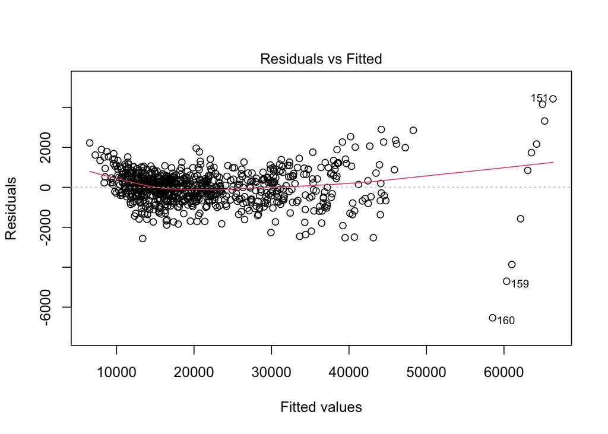

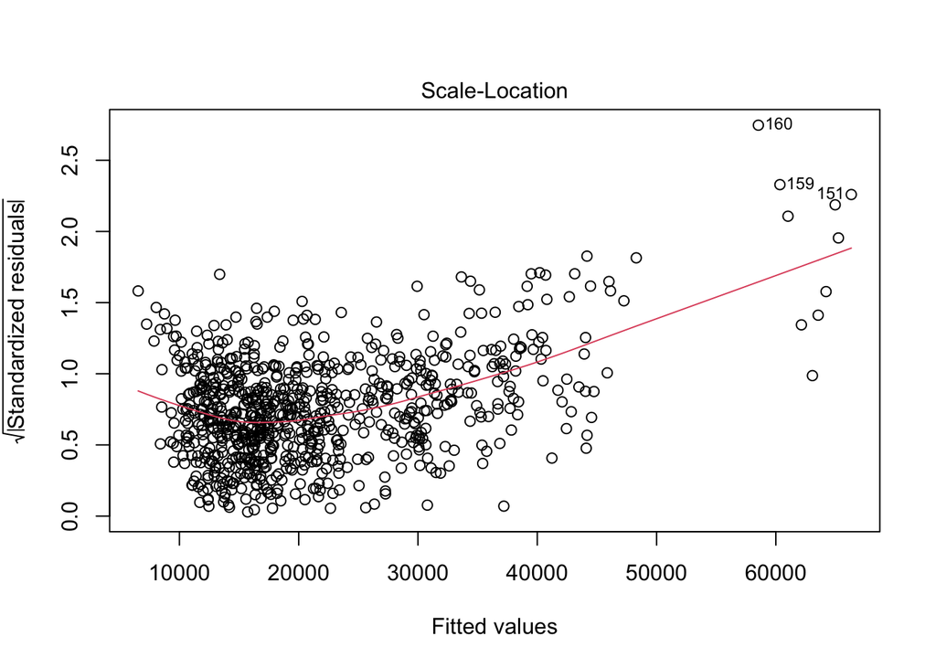

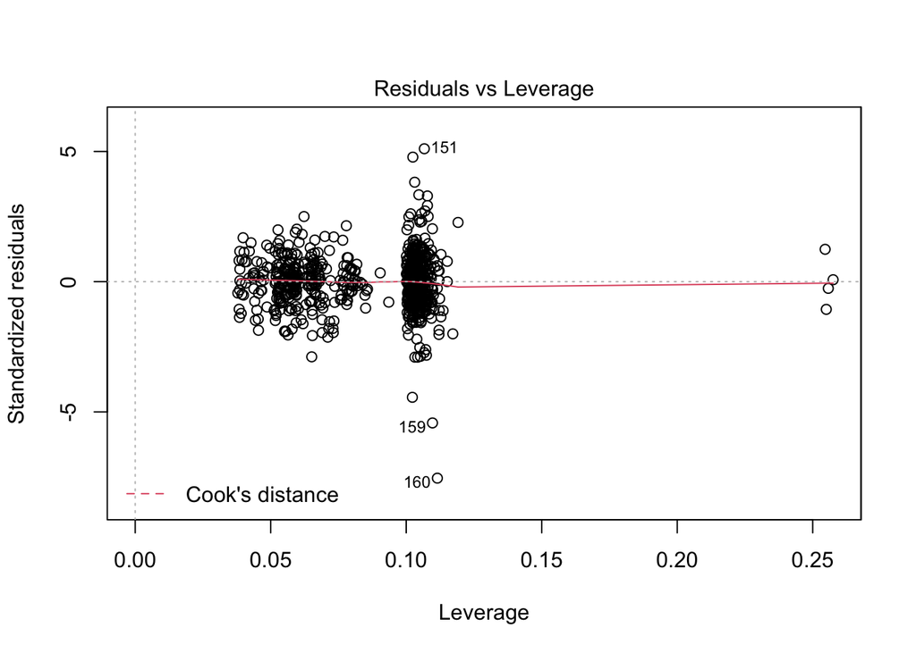

```r
plot(mod2, sub.caption = " ", which = c(1,3,5))
```

#### root standardized residuals vs fitted values find some outloiers overall

#### Find some outlier standardized residuals Vs Leverage.

```r
mod2_log_SP <- update(mod2, log(Price) ~ .)
summary(mod2_log_SP)$sigma
```

```
## [1] 0.0261353
```

```r
mae_mod2_log_SP <- mean(abs(log(kbb$Price) - mod2_log_SP$fitted.values))
mae_mod2_log_SP
```

```
## [1] 0.01927887
```

#### Estimate relative error 1.92% to 2.61% Not Bad

#### Over analysis shows that best fit model is mod2

### Writeup a short discussion summarizing the three main choices you made in

### choosing a suitable model for this problem as well as what you learn when

### trying to find a suitable model.

#### These are important point to figure out good model.

### The “best” model I was able to find has a residual standard error of roughly

### 520$ but my model could very much be overfitting to the data.

#### I am trying to do small residual standard error roughly I get around 900$

#### I know that is still high.